# D-Rex Extra: Distribution Plots from Scratch

Jonas Wallin

# 1 A Small Dataset

Open this file as an R Markdown document in RStudio and click **Knit** to create the HTML page. Run individual examples from their R code chunks; the document header and surrounding text are not R code.

In the D-Rex example, ggplot2 calculates the summaries needed for a box plot, histogram, and density plot. Here, we work through these calculations ourselves and use ggplot2 to draw the resulting lines, rectangles, and points. All the calculation code is shown, so you can follow how each observation contributes to a plot.

We use a small illustrative dataset with 13 observations. These invented values represent rounded measurements of a continuous quantity. They are chosen to include repeated observations and a value separated from the others. This example runs independently of the D-Rex data file.

```r
library(ggplot2)

values <- c(2, 3, 3, 4, 5, 5, 6, 7, 8, 8, 9, 10, 18)
n_observations <- length(values)
observations <- data.frame(value = values)

values
```

```
##  [1]  2  3  3  4  5  5  6  7  8  8  9 10 18
```

```r
n_observations
```

```
## [1] 13
```

# 2 Constructing a Box Plot

We calculate each part just before adding it to the drawing. We save the drawing as `box_plot`, then display the updated plot at each step. `annotate()` lets us draw a shape at the positions we have calculated.

The observations determine the horizontal positions. We place the box around `y = 1`; its vertical position and height are only drawing choices.

## 2.1 Step 1: Calculate the Quartiles and Draw the Box

First, we sort the observations and find the first and third quartiles. There are several conventions for sample quartiles. Here, we calculate the usual R `quantile()` convention explicitly: for a probability $p$, the position in the sorted data is $1 + (n - 1)p$, where $n$ is the number of observations. With 13 observations, the first and third quartiles are at positions 4 and 10.

If a position falls between observations, we interpolate between its two neighbours. `fraction` gives the weight on the upper neighbour. The quartiles are 4 and 8, so these become the horizontal edges, `xmin` and `xmax`, of our rectangle. `ymin` and `ymax` give its bottom and top.

We keep the same axes throughout. To leave room for the later guides, we extend the horizontal range by one quarter of the data range at each end.

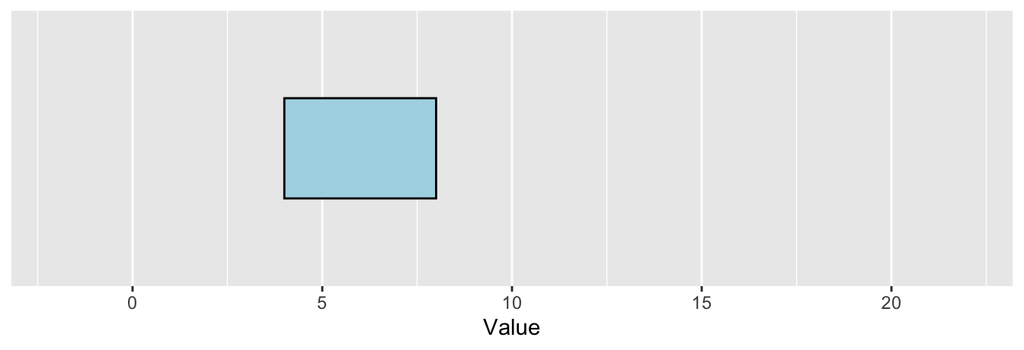

Figure 1: Step 1: the box extends from the first to the third quartile.

```r
sorted_values <- sort(values)
probabilities <- c(0.25, 0.75)
positions <- 1 + (n_observations - 1) * probabilities

lower_positions <- floor(positions)
upper_positions <- ceiling(positions)
fraction <- positions - lower_positions

box_quartiles <- (1 - fraction) * sorted_values[lower_positions] +
  fraction * sorted_values[upper_positions]
lower_quartile <- box_quartiles[1]
upper_quartile <- box_quartiles[2]

data_range <- range(values)
plot_margin <- diff(data_range) / 4
plot_limits <- data_range + c(-plot_margin, plot_margin)

box_plot <- ggplot() +
  annotate("rect", xmin = lower_quartile, xmax = upper_quartile,
           ymin = 0.8, ymax = 1.2,
           fill = "lightblue", colour = "black") +
  scale_x_continuous(limits = plot_limits) +
  scale_y_continuous(NULL, breaks = NULL, limits = c(0.5, 1.5)) +
  labs(x = "Value")

box_plot
```

## 2.2 Step 2: Calculate and Add the Median

The middle position is $(n + 1)/2$, which is 7 for our 13 observations. For an odd sample size, `floor()` and `ceiling()` pick the same observation. For an even sample size, they pick the two middle observations, whose average is the median.

Our median is 6. We draw a vertical line through the box at this value. For a line segment, `x` and `y` give its starting point, and `xend` and `yend` give its endpoint. Equal `x` and `xend` values make the line vertical.

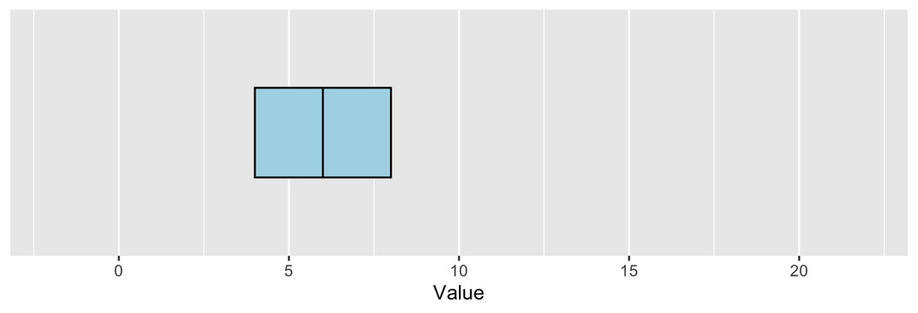

Figure 2: Step 2: a vertical line marks the median.

```r
median_position <- (n_observations + 1) / 2
median_value <- (sorted_values[floor(median_position)] +
                   sorted_values[ceiling(median_position)]) / 2

box_plot <- box_plot +
  annotate("segment", x = median_value, xend = median_value,
           y = 0.8, yend = 1.2)

box_plot
```

Here, `box_plot <- box_plot + ...` keeps the existing drawing and adds the new layer. The assignment saves this updated version for the next step.

## 2.3 Step 3: Calculate and Add the Whiskers

The *interquartile range* (IQR) is the difference between the third and first quartiles. We set fences 1.5 IQRs below the first quartile and above the third quartile. The whiskers end at the most extreme observations inside these fences.

Our IQR is 4 and our fences are -2 and 14. The whiskers therefore end at 2 and 10, rather than at the fences themselves. We connect these values to the box with horizontal lines, then draw a short vertical end cap at each endpoint.

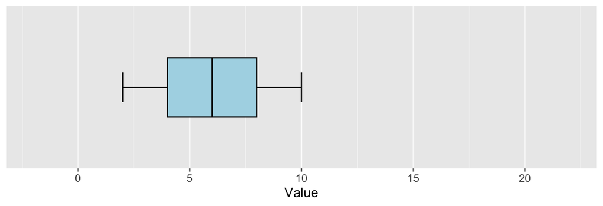

Figure 3: Step 3: the whiskers reach the most extreme observations inside the fences.

```r
interquartile_range <- upper_quartile - lower_quartile
lower_fence <- lower_quartile - 1.5 * interquartile_range
upper_fence <- upper_quartile + 1.5 * interquartile_range

inside_fences <- values >= lower_fence & values <= upper_fence
lower_whisker <- min(values[inside_fences])
upper_whisker <- max(values[inside_fences])

box_plot <- box_plot +
  annotate("segment", x = lower_whisker, xend = lower_quartile,
           y = 1, yend = 1) +
  annotate("segment", x = upper_quartile, xend = upper_whisker,
           y = 1, yend = 1) +
  annotate("segment", x = lower_whisker, xend = lower_whisker,
           y = 0.9, yend = 1.1) +
  annotate("segment", x = upper_whisker, xend = upper_whisker,
           y = 0.9, yend = 1.1)

box_plot
```

## 2.4 Step 4: Find and Add the Flagged Observation

We now select the observations outside the fences. The value 18 is flagged by this rule, so we draw it as a separate point. Being flagged does not by itself mean that an observation is incorrect. This completes the usual box plot.

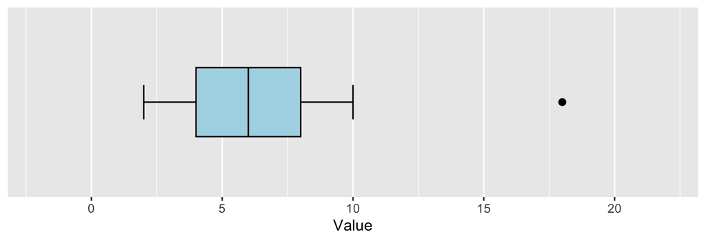

Figure 4: Step 4: the observation beyond the upper fence is drawn separately.

```r
flagged_observations <- data.frame(value = values[!inside_fences])

box_plot <- box_plot +
  geom_point(data = flagged_observations, aes(x = value, y = 1), size = 2)

box_plot
```

## 2.5 Step 5: Show the Fences and Data Positions

For this explanation, we add two guides to the completed box plot. The dotted lines show the fences at -2 and 14. The small ticks along the bottom show the observations. This makes it easier to see why the whiskers stop at 2 and 10, while 18 is drawn separately.

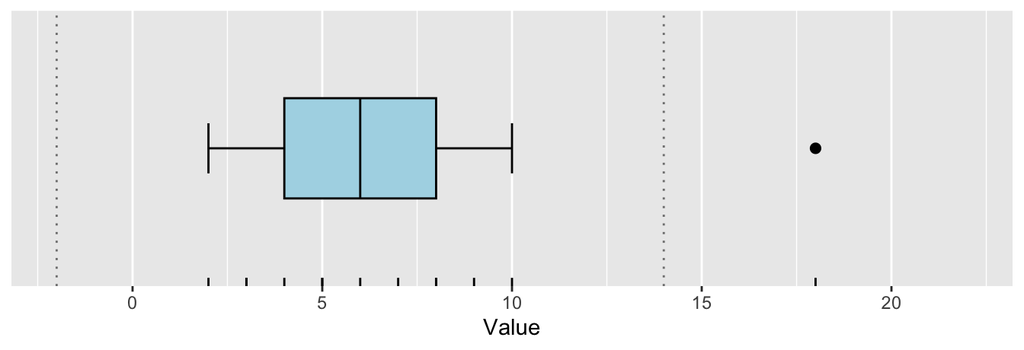

Figure 5: Step 5: dotted lines show the fences, and ticks show the data positions.

```r
box_plot <- box_plot +
  geom_vline(
    xintercept = c(lower_fence, upper_fence),
    linetype = "dotted", colour = "grey50"
  ) +
  geom_rug(data = observations, aes(x = value), sides = "b")

box_plot
```

The box plot summarizes location and spread. It does not show whether the distribution has one peak or several. For that, we need to look more directly at the shape of the distribution.

# 3 Constructing a Histogram

## 3.1 Choosing Bins and Drawing the Histogram

A histogram divides the horizontal axis into intervals, called *bins*. With only 13 observations, we choose a bin width of 4 to group neighbouring values into a few bins that are easy to count by hand. A bin for every integer would give many sparsely occupied bins. This width is an illustrative choice: smaller bins show finer detail, while larger bins combine more observations.

The observations range from 2 to 18. We place the edges at multiples of the bin width, rounding the minimum down and the maximum up to cover all the data. Thus, the first edge is 0 and the last is 20, giving five equal-width bins with boundaries at 0, 4, 8, 12, 16, and 20. Both the bin width and the starting point can affect the histogram’s appearance.

We must also decide what happens to observations exactly on a boundary. Here, each bin includes its left boundary and excludes its right boundary, so the value 4 goes into the bin from 4 to 8. We include the final right boundary in the last bin.

We count the observations in each bin, then draw one rectangle for each row of `histogram`. Its horizontal extent is given by `left` and `right`, and its height is the bin’s count. The calculations and drawing are in the same chunk so we can see how the counts become bars.

```r
bin_width <- 4
first_edge <- floor(min(values) / bin_width) * bin_width
last_edge <- ceiling(max(values) / bin_width) * bin_width
bin_edges <- seq(first_edge, last_edge, by = bin_width)
n_bins <- length(bin_edges) - 1

histogram <- data.frame(
  left = bin_edges[1:n_bins],
  right = bin_edges[2:(n_bins + 1)],
  count = integer(n_bins)
)

for (bin in seq_len(n_bins)) {
  in_bin <- values >= histogram$left[bin] &
    values < histogram$right[bin]

  if (bin == n_bins) {
    in_bin <- values >= histogram$left[bin] &
      values <= histogram$right[bin]
  }

  histogram$count[bin] <- sum(in_bin)
}

knitr::kable(histogram)
```

| left | right | count |
| --- | --- | --- |
| 0 | 4 | 3 |
| 4 | 8 | 5 |
| 8 | 12 | 4 |
| 12 | 16 | 0 |
| 16 | 20 | 1 |

```r
sum(histogram$count)
```

```
## [1] 13
```

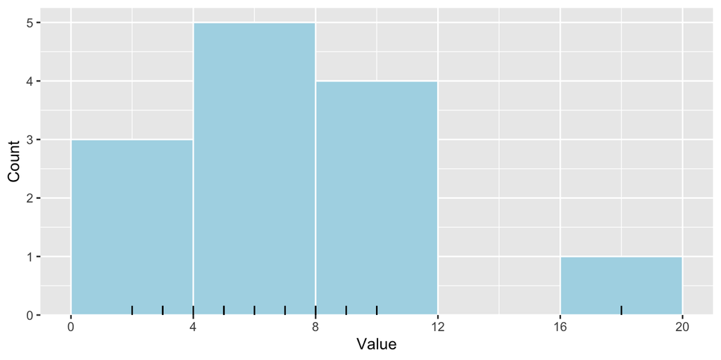

Figure 6: A histogram drawn from manually counted bins.

```r
histogram_plot <- ggplot(histogram) +
  geom_rect(aes(xmin = left, xmax = right, ymin = 0, ymax = count),
            fill = "lightblue", colour = "white") +
  geom_rug(data = observations, aes(x = value), sides = "b") +
  scale_x_continuous(breaks = bin_edges) +
  scale_y_continuous(breaks = 0:max(histogram$count),
                     expand = expansion(mult = c(0, 0.05))) +
  labs(x = "Value", y = "Count")

histogram_plot
```

The counts are 3, 5, 4, 0, and 1. They add up to 13, so every observation has been counted once. We keep the empty bin from 12 to 16: it shows a gap in the data.

## 3.2 How ggplot2 Creates a Histogram

This is the same statistical construction used by `geom_histogram()`: its `stat_bin()` step assigns observations to bins and calculates the counts, then the geom draws the bars. ggplot2 uses different internal code to perform the counting, rather than our explicit loop.

To reproduce our histogram, we supply the same `breaks` and use `closed = "left"` to include each bin’s left edge. Without these settings, ggplot2’s defaults need not match our example: it uses 30 bins when neither `bins` nor `binwidth` is specified, and includes right edges by default. See the [ggplot2 histogram documentation](https://ggplot2.tidyverse.org/reference/geom_histogram.html).

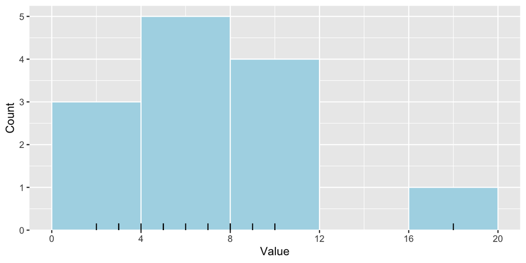

Figure 7: The same histogram made with geom_histogram() and matching bin boundaries.

```r
ggplot_histogram <- ggplot(observations, aes(x = value)) +
  geom_histogram(breaks = bin_edges, closed = "left",
                 fill = "lightblue", colour = "white") +
  geom_rug(sides = "b") +
  scale_x_continuous(breaks = bin_edges) +
  scale_y_continuous(breaks = 0:max(histogram$count),
                     expand = expansion(mult = c(0, 0.05))) +
  labs(x = "Value", y = "Count")

ggplot_histogram
```

## 3.3 Changing Counts to Densities

A histogram can also show density instead of counts. Divide each count by the number of observations and by the bin’s width:

$$\text{density height} =
\frac{\text{bin count}}{\text{number of observations}\times\text{bin width}}.$$

The *area* of each bar then equals the fraction of observations in that bin, and the total area of all the bars is one. A density height is not itself a probability; an area over an interval represents a probability. This is the quantity ggplot2 provides as `after_stat(density)`.

```r
histogram$width <- histogram$right - histogram$left
histogram$proportion <- histogram$count / n_observations
histogram$density <- histogram$proportion / histogram$width

knitr::kable(histogram, digits = 4)
```

| left | right | count | width | proportion | density |
| --- | --- | --- | --- | --- | --- |
| 0 | 4 | 3 | 4 | 0.2308 | 0.0577 |
| 4 | 8 | 5 | 4 | 0.3846 | 0.0962 |
| 8 | 12 | 4 | 4 | 0.3077 | 0.0769 |
| 12 | 16 | 0 | 4 | 0.0000 | 0.0000 |
| 16 | 20 | 1 | 4 | 0.0769 | 0.0192 |

```r
sum(histogram$density * histogram$width)
```

```
## [1] 1
```

# 4 Constructing a Kernel Density Estimate

A *kernel density estimate* (KDE) is another way to display a distribution. Instead of putting each observation into a bin, we place a small curve, called a *kernel*, around each observation, then average the heights of these curves.

## 4.1 Placing a Gaussian Kernel at Each Observation

We use Gaussian kernels. Each curve is centred on one observation and has total area one. Its standard deviation is the *bandwidth*. Choosing Gaussian kernels does not mean that the data are assumed to follow a Gaussian distribution.

We choose a bandwidth of 1.5 to illustrate the calculation: nearby observations contribute overlapping curves, while the isolated observation remains visible. Smaller bandwidths show more detail; larger bandwidths produce more smoothing. See the Density Plot section of the D-Rex example for a comparison of bandwidths.

Let $x_i$ be observation $i$, let $t$ be a position along the horizontal axis, and let $h$ be the bandwidth. The height of observation $i$’s kernel at $t$ is

$$k_i(t) = \frac{1}{h\sqrt{2\pi}}
\exp\left[-\frac{1}{2}\left(\frac{t-x_i}{h}\right)^2\right].$$

We evaluate this formula on a grid of positions. The grid extends four bandwidths beyond the smallest and largest observations so we can see most of the tails. The Gaussian curves continue beyond the displayed range.

`expand.grid()` creates one row for each combination of a grid position and an observation number. The observation number matters: the two observations at 3 must each contribute a kernel, even though their curves coincide.

We draw one line for each observation using `group = observation`. Curves for repeated values lie on top of each other. The ticks show the data positions. For these ticks, `inherit.aes = FALSE` lets the rug layer use its own mapping: it only needs the observed values, not the kernel heights or observation groups.

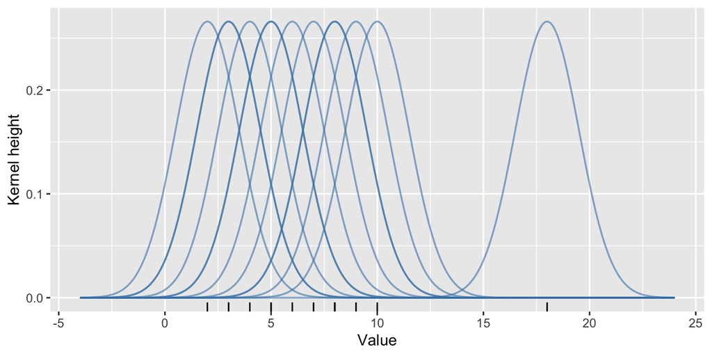

Figure 8: One Gaussian kernel per observation, with bandwidth 1.5. Repeated observations produce overlapping curves.

```r
bandwidth <- 1.5
x_grid <- seq(min(values) - 4 * bandwidth,
              max(values) + 4 * bandwidth,
              length.out = 501)

kernels <- expand.grid(
  x = x_grid,
  observation = seq_len(n_observations)
)
kernels$centre <- values[kernels$observation]
kernels$height <- exp(-0.5 * ((kernels$x - kernels$centre) / bandwidth)^2) /
  (bandwidth * sqrt(2 * pi))

ggplot(kernels, aes(x = x, y = height, group = observation)) +
  geom_line(colour = "steelblue", alpha = 0.6, linewidth = 0.6) +
  geom_rug(data = observations, aes(x = value),
           inherit.aes = FALSE, sides = "b") +
  labs(x = "Value", y = "Kernel height")
```

## 4.2 Averaging the Kernels

At each grid position, add the heights of all 13 kernels and divide by 13. The resulting curve is the kernel density estimate:

$$\widehat f(t) = \frac{1}{n}\sum_{i=1}^{n} k_i(t),$$

where $n$ is the number of observations. We use a loop to make this averaging step explicit. At each position, `at_this_position` selects the 13 kernel heights to average.

Since each kernel has area one, their average also has area one over the whole real line. Every observation, including 18, contributes to this curve. Repeated observations contribute repeatedly; we average over observations, not over distinct values.

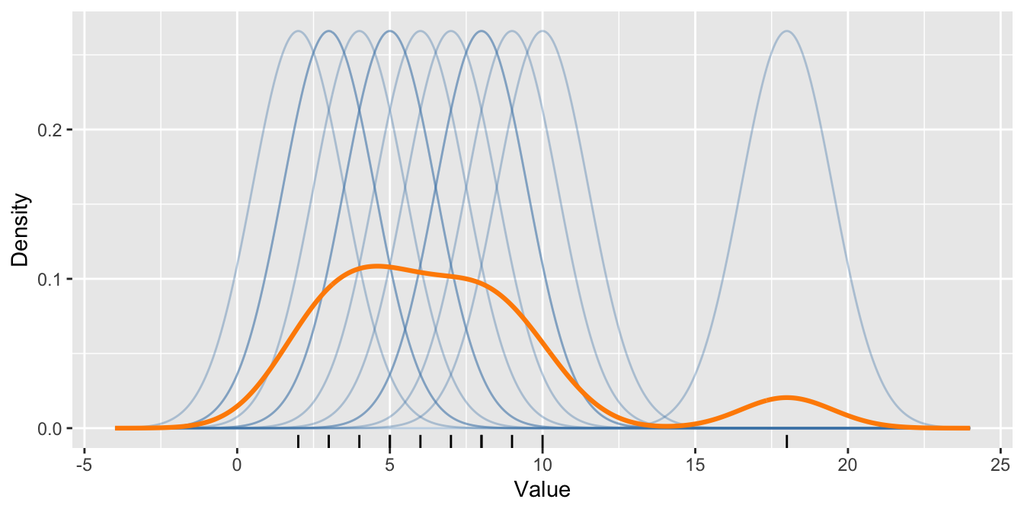

Figure 9: The orange curve is the average of the individual blue kernels.

```r
density_estimate <- data.frame(x = x_grid, density = NA_real_)

for (position in seq_along(x_grid)) {
  at_this_position <- kernels$x == x_grid[position]
  density_estimate$density[position] <-
    sum(kernels$height[at_this_position]) / n_observations
}

ggplot() +
  geom_line(data = kernels,
            aes(x = x, y = height, group = observation),
            colour = "steelblue", alpha = 0.35, linewidth = 0.5) +
  geom_line(data = density_estimate, aes(x = x, y = density),
            colour = "darkorange", linewidth = 1.1) +
  geom_rug(data = observations, aes(x = value), sides = "b") +
  labs(x = "Value", y = "Density")
```

# 5 A Rectangular Kernel

Replace each Gaussian curve with a rectangle centred on its observation. With half-width $a$, the kernel has height $1/(2a)$ inside its interval and zero outside, giving area one. We set $a = \sqrt{3}h$ to keep its standard deviation equal to the earlier bandwidth $h$, following [R’s bandwidth convention](https://stat.ethz.ch/R-manual/R-devel/library/stats/html/density.html).

The averaging is unchanged, but the result is a step curve. We include the rectangle edges in the grid so `geom_step()` places the jumps correctly.

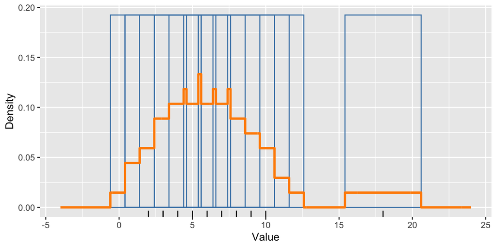

Figure 10: The orange step curve is the average of the individual rectangular kernels.

```r
rectangular_bandwidth <- bandwidth
half_width <- sqrt(3) * rectangular_bandwidth

rectangular_kernels <- data.frame(
  left = values - half_width,
  right = values + half_width,
  height = 1 / (2 * half_width)
)

rectangular_grid <- sort(unique(c(x_grid, rectangular_kernels$left,
                                  rectangular_kernels$right)))
rectangular_density <- data.frame(x = rectangular_grid, density = NA_real_)

for (position in seq_along(rectangular_grid)) {
  inside_rectangle <- rectangular_grid[position] >= rectangular_kernels$left &
    rectangular_grid[position] < rectangular_kernels$right

  rectangular_density$density[position] <-
    sum(rectangular_kernels$height[inside_rectangle]) / n_observations
}

ggplot() +
  geom_rect(data = rectangular_kernels,
            aes(xmin = left, xmax = right, ymin = 0, ymax = height),
            fill = NA, colour = "steelblue", alpha = 0.3) +
  geom_step(data = rectangular_density, aes(x = x, y = density),
            direction = "hv", colour = "darkorange", linewidth = 1.1) +
  geom_rug(data = observations, aes(x = value), sides = "b") +
  labs(x = "Value", y = "Density")
```